# PG2-Informe

#### **EDAD y CAPACITACIÓN_INC**

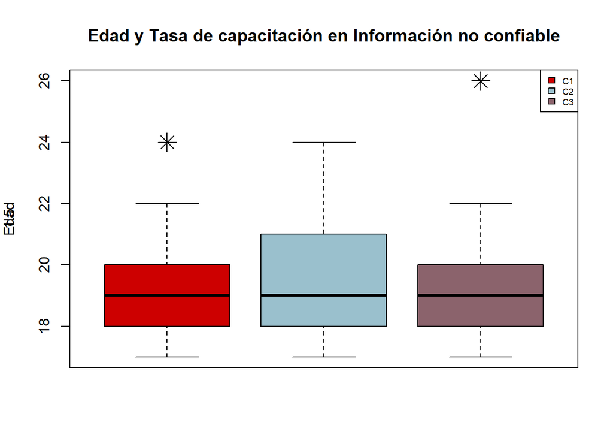

#### **TIEMPO DE DEMORA y NIVEL DE CONFIANZA**

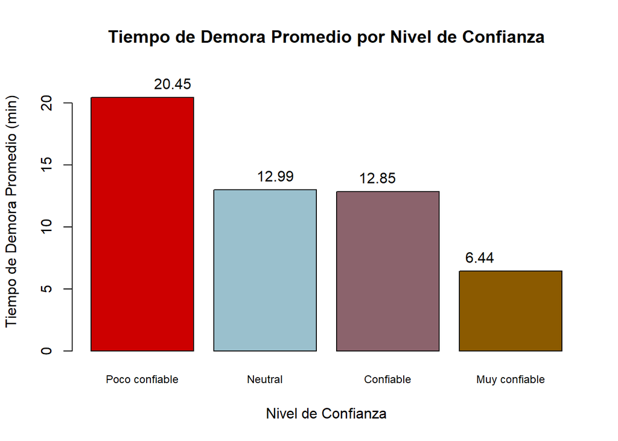

##### - **Análisis**

- Al contrastar estos dos conjuntos de datos, se encuentra una correlación interesante. Se observa que aquellos estudiantes que informaron un tiempo de demora aproximado de 20 minutos en consultar una fuente tienen un nivel de confianza más bajo en comparación con los que consultan en menor tiempo. A medida que aumenta el nivel de confianza, se observa una disminución en el tiempo de demora en analizar una fuente. Por lo tanto, se deduce que las personas que tienen menos confianza en la fuente tienden a demorarse más en su análisis.